# Cartographie statique avec mapsf

Author

Claude Grasland

Le package *mapsf* permet de réaliser des cartes statiques de très haute qualité. Il a en effet été mis au point par des cartographes et des géomaticiens professionnels de l’UMS RIATE. Il prend la suite du package *cartography* dont la maintenance demeurera assuré quelque temps encore mais ne fera plus l’objet de développements futurs. Le package *mapsf* présente l’avantage d’être totalement compatibvle avec le package *sf* ce qui n’était pas autant le cas pour le package *cartography*, plus ancien, et créé pour être compatible avec l’ancien package *sp*.

On trouvera la documentation du package mapsf à l’adresse suivante :

https://riatelab.github.io/mapsf/index.html

## Création d’un template cartographique

Nous allons dans un premier temps apprendre à créer un fonds de carte vierge mais comportant tout l’habillage nécessaire (“template”). Pour cela nous allons charger différentes couches cartographiques correspondant respectivement au département, aux communes et aux iris.

Afin d’éviter les déformations, les fonds de carte sont projetés selon la projection de référence en France (code 2154)

```r
map_iris<-readRDS("parisPC/geom/map_iris_csp.RDS") %>% st_transform(crs=2154)
map_com <-readRDS("parisPC/geom/map_com_csp.RDS") %>% st_transform(crs=2154)
map_dep <-readRDS("parisPC/geom/map_dep.RDS") %>% st_transform(crs=2154)
```

### tracé d’un fonds de carte vierge

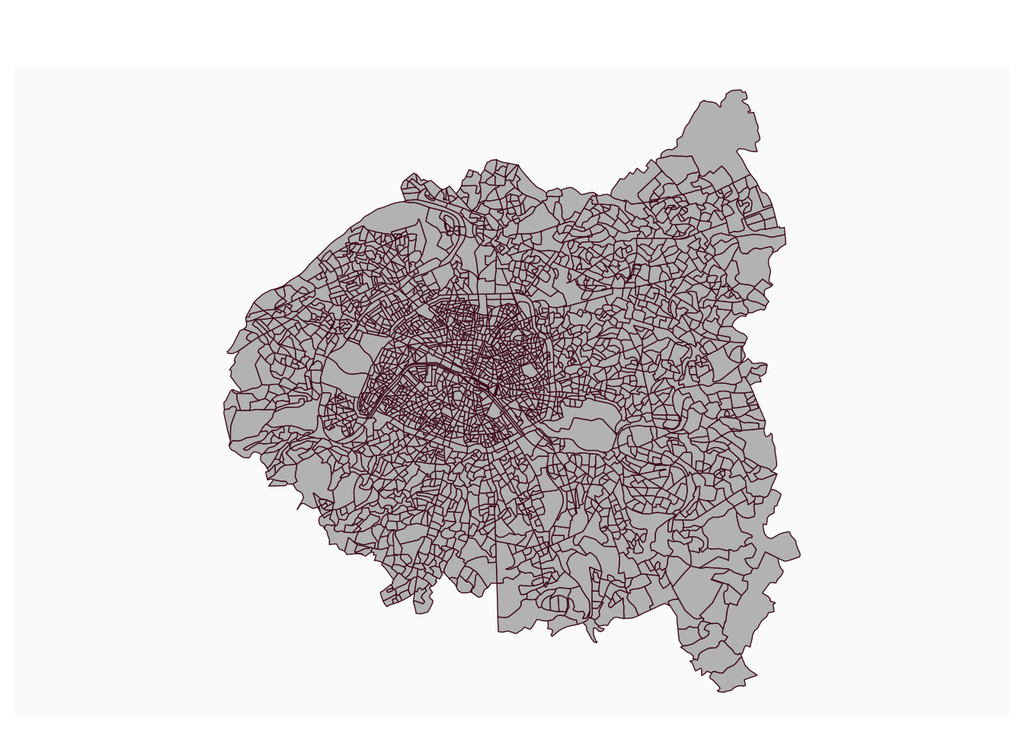

```r
 mf_map(map_iris, type = "base")
```

### Superposition de couches

On peut toutefois ajouter toute une série de paramètres supplémentaire (`col=`, `border=`, `lwd=`, …) et superposer plusieurs fonds de carte avec le paramètre `add = TRUE`. L’ajout de la fonction `layout` permet de rajouter un cadre une légende.

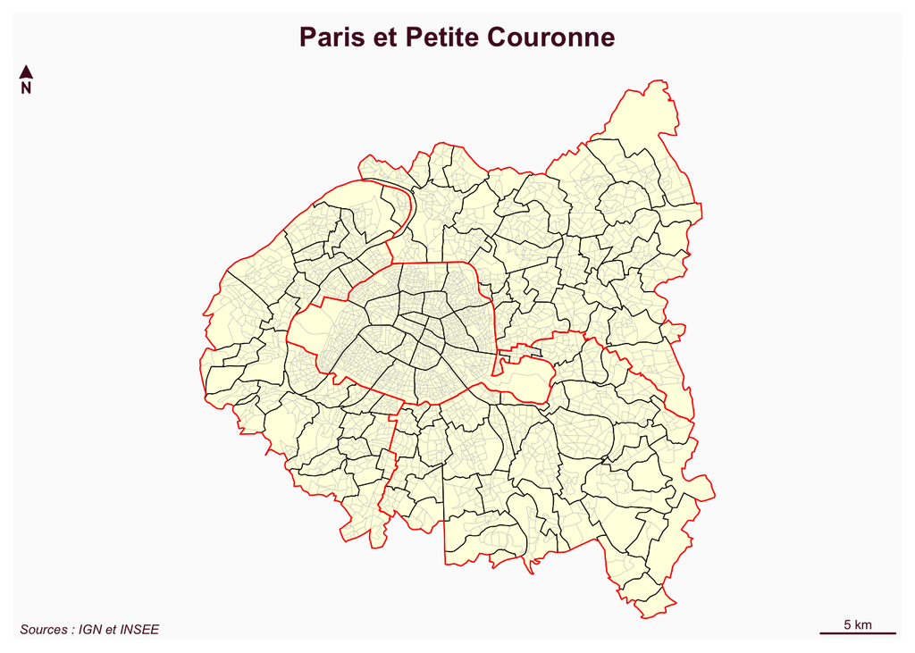

```r
# Trace les Iris avec des paramètres
mf_map(map_iris,  type = "base",
       col = "lightyellow", border="gray80",lwd=0.3)
# Ajoute les contours des communes
mf_map(map_com,  type = "base",
       col = NA,border="black",lwd=0.6,
       add = TRUE)
# Ajoute les contours des départements
mf_map(map_dep,  type = "base",
       col = NA,border="red",lwd=1,
       add = TRUE)

# Ajoute un cadre, un titre et des sources
mf_layout(title = "Paris et Petite Couronne",
          credits = "Sources : IGN et INSEE")
```

### Ajout d’un thème

On peut finalement modifier l’ensemble de la carte en lui ajoutant une instruction `mf_theme()` qui peut reprendre des styles existants ( *“default”, “brutal”, “ink”, “dark”, “agolalight”, “candy”, “darkula”, “iceberg”, “green”, “nevermind”, “jsk”, “barcelona”*) mais aussi créer ses propres thèmes

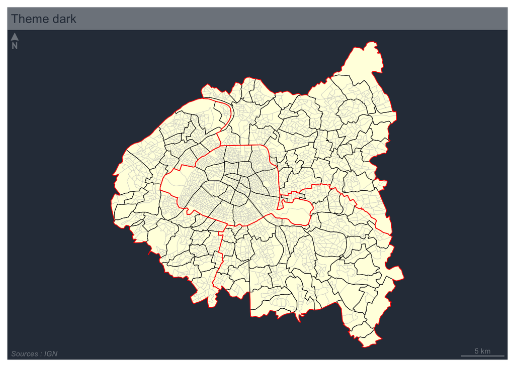

```r
#Choix du thème
mf_theme("dark")
# Trace les Iris avec des paramètres
mf_map(map_iris,  type = "base",
       col = "lightyellow", border="gray80",lwd=0.3)
# Ajoute les contours des communes
mf_map(map_com,  type = "base",
       col = NA,border="black",lwd=0.6,
       add = TRUE)
# Ajoute les contours des départements
mf_map(map_dep,  type = "base",
       col = NA,border="red",lwd=1,
       add = TRUE)

mf_layout(title = "Theme dark",
          credits = "Sources : IGN ")
```

Autre exemple

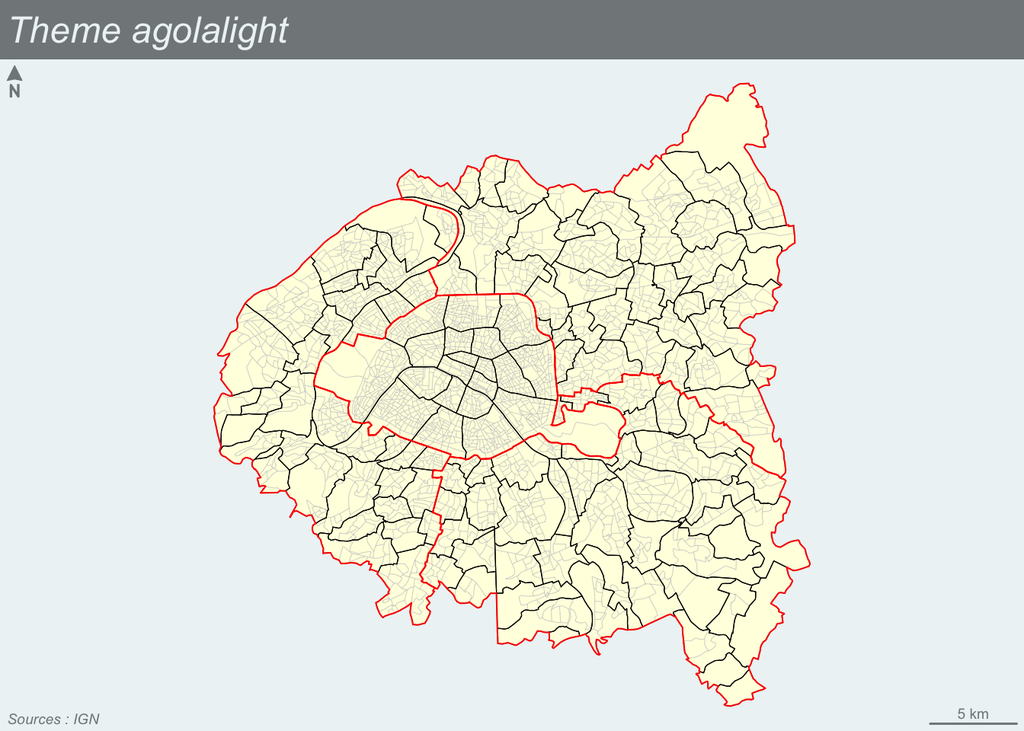

```r
#Choix du thème
mf_theme("agolalight")
# Trace les Iris avec des paramètres
mf_map(map_iris,  type = "base",
       col = "lightyellow", border="gray80",lwd=0.3)
# Ajoute les contours des communes
mf_map(map_com,  type = "base",
       col = NA,border="black",lwd=0.6,
       add = TRUE)
# Ajoute les contours des départements
mf_map(map_dep,  type = "base",
       col = NA,border="red",lwd=1,
       add = TRUE)

mf_layout(title = "Theme agolalight",
          credits = "Sources : IGN")
```

### Ajout de texte

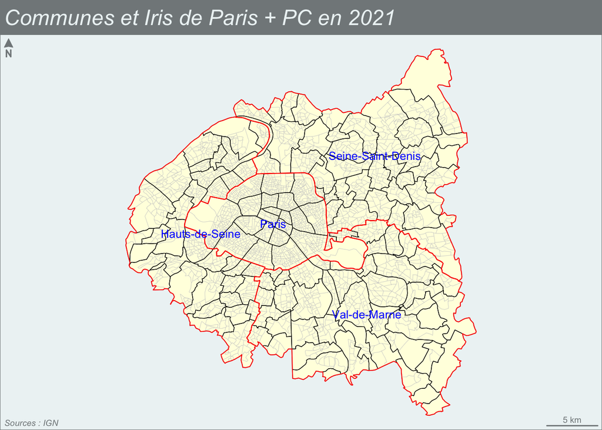

```r
#Choix du thème
mf_theme("agolalight")
# Trace les Iris avec des paramètres
mf_map(map_iris,  type = "base",
       col = "lightyellow", border="gray80",lwd=0.3)
# Ajoute les contours des communes
mf_map(map_com,  type = "base",
       col = NA,border="black",lwd=0.6,
       add = TRUE)
# Ajoute les contours des départements
mf_map(map_dep,  type = "base",
       col = NA,border="red",lwd=1,
       add = TRUE)

# Ajoute les noms des départements
mf_label(map_dep,
         var="dep_name",
         cex=0.8,
         col="blue",
         overlap = FALSE)

# Ajoute un cadre, un titre et des sources
mf_layout(title = "Communes et Iris de Paris + PC en 2021",
          frame = TRUE,
          credits = "Sources : IGN ")
```

## Carte de stock

Une *carte de stock* représente la localisation de quantités que l’on peut aditionner et dont le total a un sens. Par exemple un nombre d’habitants, un nombre de ménages, un nombre d’automobiles. Ce quantités doivent être représentées par des figures (cercles, carrés, …) dont la *surface est proportionelle au stock* afin que l’oeil du lecteur puisse les aditionner visuellement.

Dans le package **mapsf**, on réalise ce type de carte à l’aide de la fonction `mf_map()`en lui donnant le paramètre `type="prop"`.

### Carte de stock minimale

Les instructions minimales sont les suivantes :

```
100 'NA' values are not plotted on the map.
```

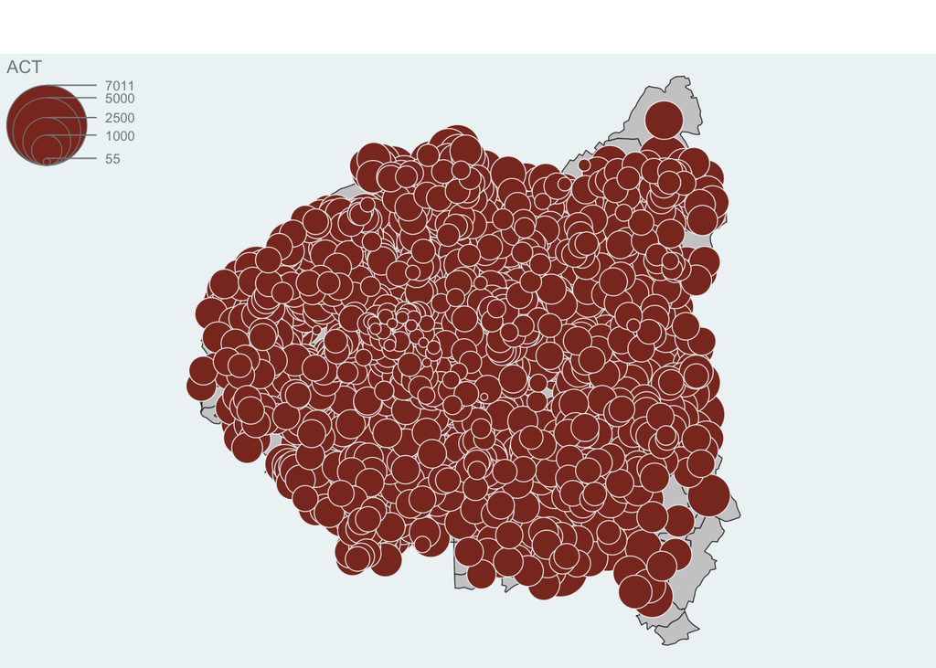

```r
# Calcule le nombre total d'actif
map_iris$ACT <- map_iris$CHO+map_iris$EMP

# Trace les contours des communes
mf_map(x= map_iris,
       type = "base")

# Ajoute le nombre d'actifs
mf_map(x =map_iris,
      type ="prop",
      var = "ACT",
      add=TRUE)
```

Mais le résultat est peu satisfaisant car les cercles sont trop grands. Il faut en pratique toujours effectuer un réglage de ceux-ci avec l’instruction `inches=`

### Carte de stock habillée

```r
mf_theme("agolalight")
mf_map(map_iris, type = "base",
       col = "lightyellow",border="gray80", lwd=0.3)
mf_map(map_com, type = "base",
       col = NA,border="black",lwd=1,add = TRUE)

mf_map(map_iris, var = "ACT",type = "prop",
  inches = 0.1, col = "red",leg_pos = "left",
  leg_title = "Nombre d'actifs", add=TRUE)
```

```
100 'NA' values are not plotted on the map.
```

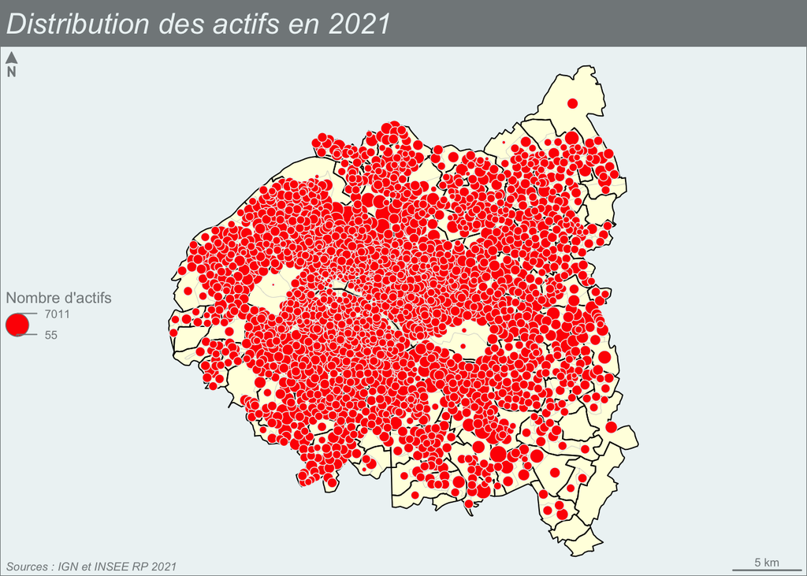

```r
mf_layout(title = "Distribution des actifs en 2021",
          frame = TRUE,
          credits = "Sources : IGN et INSEE RP 2021")
```

## Carte choroplèthe

Une *carte choroplèthe ou d’intensité* représente un phénomène relatif dont la somme n’a pas de sens. Par exemple, il serait absurde d’aditionner les % de logement HLM des IRIS du Val de Marne. Ces variables d’intensité caractèrisent donc l’état général d’une zone (*choros*) et elles vont être représentées par une couleur appliquée à toute la surface de la zone, d’où leur nom de *cartes choroplèthes*.

La fonction du package **mapsf** adaptée aux variables d’intensité est la fonction `mf_map()`munie du paramètre `type = "choro"`.

On va prendre l’exemple du taux de chômage

```r
map_iris$TxCHO<-100*map_iris$CHO/map_iris$ACT
```

### Carte choroplèthe minimale

Si on ne précise rien, la carte est réalisée à l’aide de la palette par défaut avec un découpage des classes en quantiles (effectifs égaux).

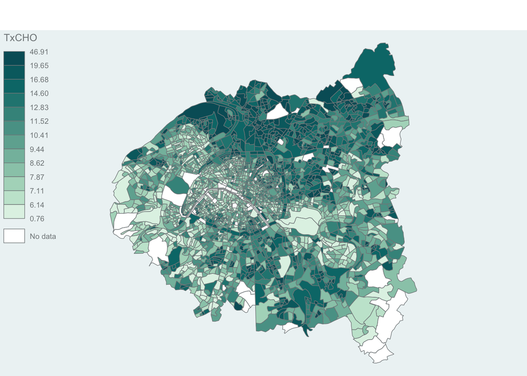

```r
# Carte choroplèthe
mf_map(
  x = map_iris,
  var = "TxCHO",
  type = "choro")
```